# Part II - ProsperLoan: Top Borrowers and Their Unique Characteristics

## Loan Distribution From 2006 - 2014

From 2006 to 2014, individuals from several walks of life requested loan to fund one financial obligation or the other. A distribution of the years with respect to loan listings shows that there was a slow but progressive increase from 2006 to 2008 when the first significant dip was experienced. Then in 2009, there was a major dip, a drought as a matter of fact. I assume this was due to the recession going on at the time (The Great Recession, 2007 - 2009). Plus, 2009, was the year that had the peak unemployment rate (10% in October). I believe the reason for this is that given the circumstances, many lenders were unwilling to give out funds at this time as this could cause them to become financial vulnerable and susceptible to loans since ProsperLoan is a peer-to-peer loan company.

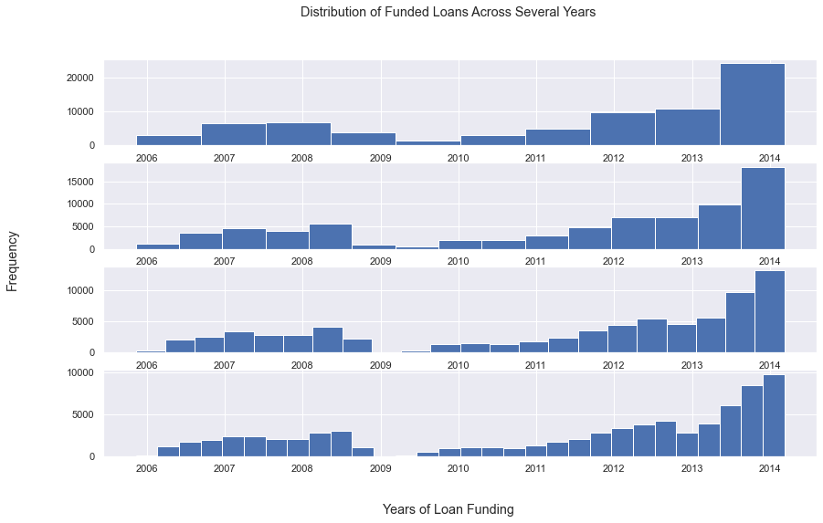

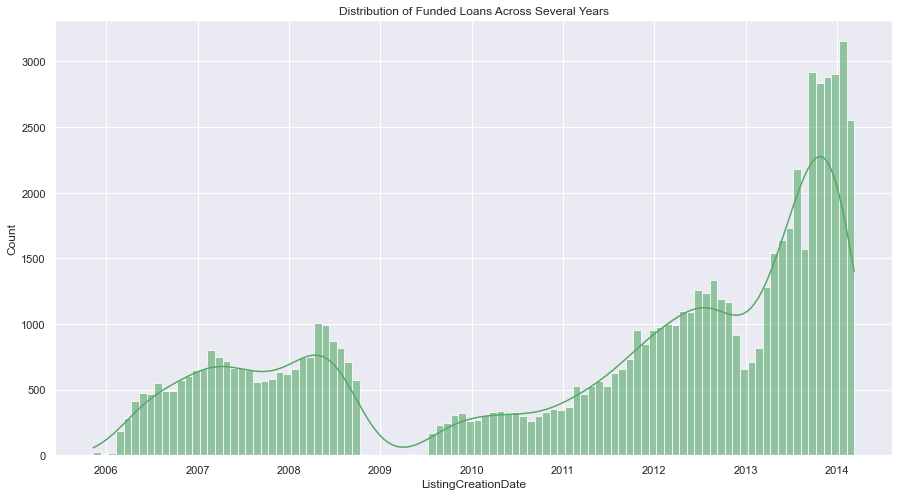

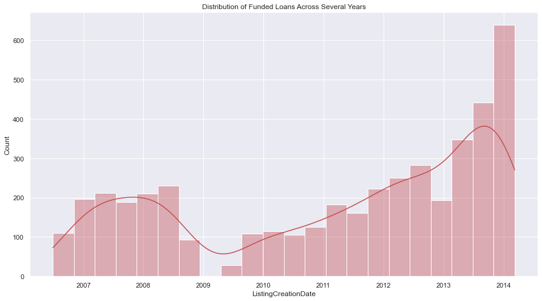

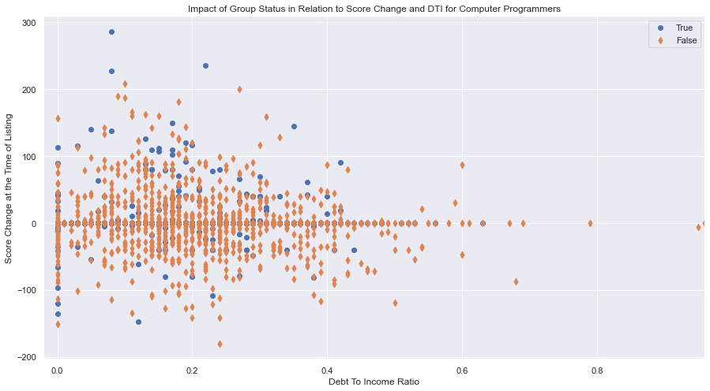